# Pertemuan 3 - Regresi dengan Peubah Lag

Jonathan Marjono (G1401211064)

## 1. Pendahuluan

### 1.1 Latar Belakang

Seiring perkembangan zaman, kebutuhan energi listrik di Indonesia semakin meningkat. Krisis listrik sudah ada sejak lama dan hal tersebut menjadi sebuah persoalan, yang berlandaskan hasil prediksi para ahli. Kebutuhan akan energi ini akan meningkat secara eksponensial, sehingga diperlukan sebuah energi baru yang mampu memenuhi kebutuhan listrik nasional yang semakin besar. Salah satu yang menjadi penentu hal ini yakni sumber tersebut haruslah berasal dari sumber daya yang dapat terbaharukan, tersedia di alam, serta mudah untuk dimanfaatkan. Sebagai solusi adalah adanya energi angin yang cenderung masih jarang dimanfaatkan sebagai energi yang mendukung kehidupan sehari-hari (Lubis Z. 2018). Disisi lain kincir angin dapat menghasilkan listrik dengan tenaga utama yang digunakan adalah angin yang merupakan sumber daya terbarukan yang cukup besar. Dengan sistem kerja yang cukup sederhana dengan angin yang menggerakan putaran baling-baling akan mendapatkan sebuah perubahan pada gerak. Dari putaran kincir tersebut akan disalurkan kepada dinamo yang dapat menghasilkan listrik (Bektiarso *et al*. 2023).

Pada penelitian ini, akan dilakukan analisis regresi pada data daya yang dihasilkan per 10 menit. Analisis yang dilakukan adalah menganalisis hubungan antara daya yang dihasilkan dengan kecepatan angin, serta rotasi putaran kincir selama 144 periode (nantinya akan dipilih satu peubah x saja). Analisis regresi akan dilakukan dengan menggunakan metode model koyck, distribusi lag, dan model autoregressive.

### 1.2 Tujuan

1. Menganalisis hubungan antara daya dengan kecepatan angin atau rotasi kincir
2. Melakukan penanganan autokorelasi model regresi deret waktu dengan metode distribusi lag
3. Membandingkan keakuratan ramalan antara model koyck, distibusi lag, dan model autoregressive.

### 1.3 Tinjauan Pustaka

Analisis regresi adalah teknik analisis data untuk menentukan hubungan sebab akibat antara variabel *dependent* (Y) dan satu atau lebih variabel *independent* (X). Analisis regresi dengan serangkaian pengamatan terhadap suatu peristiwa diambil dari waktu ke waktu merupakan analisis regresi deret waktu (Gujarati 2006). Waktu yang diperlukan bagi variabel bebas (X) dalam memengaruhi variabel takbebas (Y) disebut beda kala atau lag (Sarwoko 2005). Model regresi dengan memasukkan nilai variabel yang menjelaskan nilai masa kini atau nilai masa lalu dari variabel bebas (X) sebagai tambahan pada model yang memasukkan lag dari variabel tak bebas (X) disebut *autoregressive distributed lag* (ARDL). Metode Koyck didasari asumsi bahwa semakin jauh jarak lag pada variabel bebas dari periode sekarang maka semakin kecil pengaruh variabel lag terhadap variabel tak bebas (Gujarati 2004).

**Asumsi Klasik Model Regresi**

Asumsi-asumsi klasik menurut Gujarati (2006) yaitu sebagai berikut:

1. Variabel Xi dan Xj tidak berkorelasi dengan faktor galat u.
2. Nilai harapan/rataan galat sama dengan nol.
3. Homoskedastisitas atau ragam sisaan homogen untuk setiap x, Var(u) = $\sigma^2$
4. Tidak ada autokorelasi antar faktor galat ui dan uj atau cov(ui,uj)=0,
5. Tidak ada kolinearitas antara Xi dan Xj.

## *2. Packages*

Menginstall packages serta memanggil beberapa library.

```r
#install.packages("dLagM") #install jika belum ada
#install.packages("dynlm") #install jika belum ada
#install.packages("MLmetrics") #install jika belum ada
library(dLagM)
library(dynlm)
library(MLmetrics)
library(lmtest)
library(car)
```

## 3. Impor Data

Mengimpor data penuhnya yang bersumber dari kaggle yakni data wind power forecasting dari tahun 2017-2020. Dengan menggunakan library rio, dipanggil data tersebut dari link github author, pada folder penugasan responsi 3.

```r
#Dengan library "rio"
dataset <- rio::import("https://raw.githubusercontent.com/jonathanmarjonoxz/MPDW/main/Responsi3/Turbine_Data.csv")
#Melihat dimensi jumlah baris dan kolom data
dim(dataset)
```

```
## [1] 118224     22
```

```r
View(dataset) #Melihat isi data
```

Membuat t dari 1-144 dengan selang antar periode 10 menit, lalu ingin diketahui hubungan antara daya yang dihasilkan (ActivePower) kincir dengan putaran rotor (RotorRPM) dengan dengan durasi 144 periode waktu. Dibuat sebuah data dengan urutan penamaan kolom t, Yt, Y(t-1), serta Xt.

```r
#Mengambil sebanyak 144 periode
data <- dataset[118081:nrow(dataset),c(2,18)]
#Mengubah penamaan menjadi Yt serta Xt
colnames(data) <- c("Yt","Xt")

#Library untuk proses penambahan kolom ataupun baris
library(tibble)
#Menambah kolom t dari 1-144
data <- add_column(data, t=rep(1:144), .before="Yt")
#Membuat kolom Y(t-1)
Y <- data[c(NA,1:143), 2]
#Menggabungkan kolom Y(t-1)
data <- add_column(data,"Y(t-1)"=Y, .after="Yt")

#Memeriksa hasil data yang dimasukkan
rownames(data) <- rep(1:144)
View(data)
```

## 4. Pembagian Data

Dibagi data train dan test sebesar 75% untuk train serta 25% untuk test

```r
banyaktrain <- (75/100)*nrow(data)
banyaktest <- (25/100)*nrow(data)
cbind(banyaktrain,banyaktest)
```

```
##      banyaktrain banyaktest
## [1,]         108         36
```

```r
#Split Data
train <- data[1:108,]
test <- data[109:144,]
```

```r
#Data time series
train.ts<-ts(train)
test.ts<-ts(test)
data.ts<-ts(data)
```

## 5. Exploratory Data Analysis

### 5.1 Time Series Plot of ActivePower

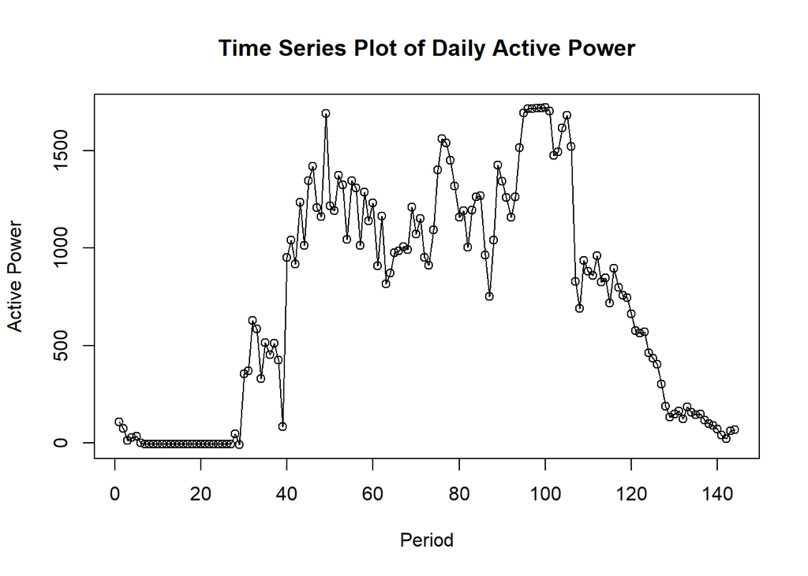

```r
data.ts1<-ts(data$Yt)
plot(data.ts1, main = "Time Series Plot of Daily Active Power", xlab = "Period", ylab="Active Power")
points(data.ts1)
```

Peubah ActivePower akan dijadikan sebagai peubah respon untuk analisis regresi.

### 5.2 Time Series Plot of RotorRPM

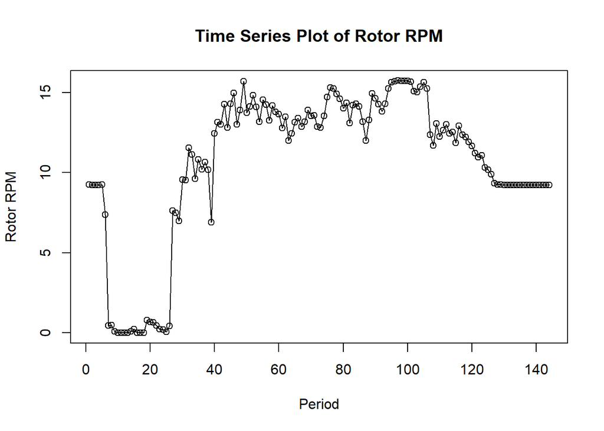

```r
#Time Series Plot
data.ts<-ts(data$Xt)
plot(data.ts, main = "Time Series Plot of Rotor RPM", xlab = "Period", ylab="Rotor RPM")
points(data.ts)
```

Peubah rotorRPM ini akan dijadikan sebagai peubah penjelas untuk analisis regresi.

### 5.3 Korelasi Peubah Rotor RPM (X) dengan Active Power(Y)

```r
cor(data$Xt,data$Yt)
```

```
## [1] 0.8516001
```

### 5.4 Scatter Plot Peubah Rotor RPM (X) dengan Active Power(Y)

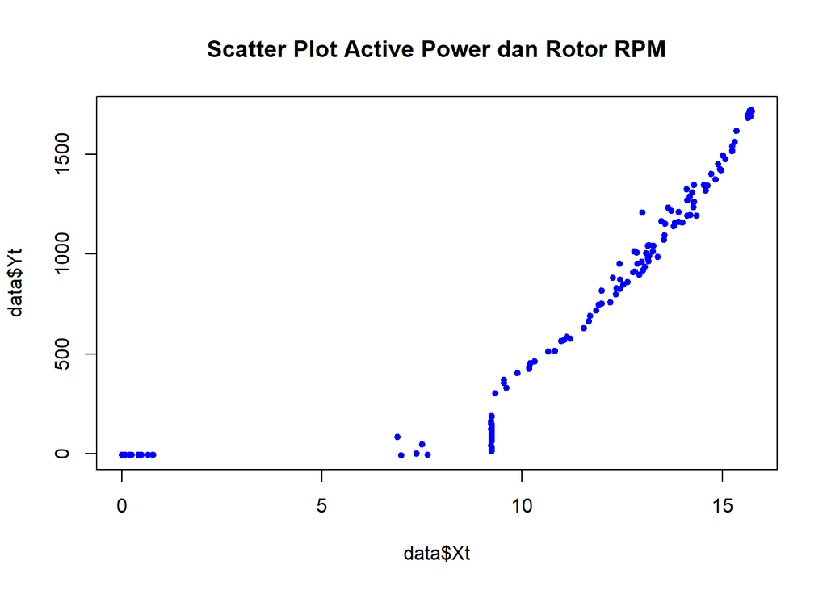

```r
plot(data$Xt, data$Yt, pch = 20, col = "blue", main = "Scatter Plot Active Power dan Rotor RPM")
```

Berdasarkan scatter plot terlihat hubungan antara peubah active power dengan rotor RPM memiliki hubungan linier positif dengan nilai korelasi 0.8516001.

### 5.5 Model Regresi Awal

```r
model1 <- lm(data$Yt~data$Xt, data = data)
summary(model1)
```

```
##
## Call:
## lm(formula = data$Yt ~ data$Xt, data = data)
##
## Residuals:
##    Min     1Q Median     3Q    Max
## -579.4 -237.7   35.2  276.0  461.6
##
## Coefficients:
##             Estimate Std. Error t value Pr(>|t|)
## (Intercept) -362.871     61.931  -5.859  3.1e-08 ***
## data$Xt      103.205      5.331  19.359  < 2e-16 ***
## ---
## Signif. codes:  0 '***' 0.001 '**' 0.01 '*' 0.05 '.' 0.1 ' ' 1
##
## Residual standard error: 301.3 on 142 degrees of freedom
## Multiple R-squared:  0.7252, Adjusted R-squared:  0.7233
## F-statistic: 374.8 on 1 and 142 DF,  p-value: < 2.2e-16
```

Berdasarkan output diatas, diperoleh model regresi linier data deret waktu yaitu:

$Yt = -362.871 + 103.205X_t$

- **Uji t** : Uji t dilakukan untuk menguji signifikansi peubah penjelas terhadap *variabel dependent*. Berdasarkan output, diperoleh bahwa pada peubah penjelas memiliki *P-Value*<0.05 sehingga dapat disimpulkan bahwa peubah penjelas rotorRPM berpengaruh signifikan pada taraf nyata 5%.
- **Nilai R-Squared** pada model regresi linier deret waktu yaitu 72.52%, artinya keragaman Active Power dapat dijelaskan oleh RotorRPM sebesar 72.52%, sehingga model regresi ini dapat dikatakan cukup baik.

### 5.6 Uji Asumsi Autokorelasi

```r
bgtest(model1)
```

```
##
##  Breusch-Godfrey test for serial correlation of order up to 1
##
## data:  model1
## LM test = 115.54, df = 1, p-value < 2.2e-16
```

Diperoleh *p-value* kurang dari 0.05, artinya tolak H0. Sehingga cukup bukti untuk menyatakan terdapat autokorelasi pada model awal dengan taraf nyata 5%. Karena adanya autokorelasi, akan dilakukan penanganan dengan menambahkan lag tertentu. Metode yang akan digunakan adalah:

1. Model Koyck,
2. Distributed Lag, dan
3. Autoregressive Distributed Lag (ARDL).

## 6. Model Koyck

Model Koyck didasarkan pada asumsi bahwa semakin jauh jarak lag peubah independen dari periode sekarang maka semakin kecil pengaruh peubah lag terhadap peubah dependen.

Koyck mengusulkan suatu metode untuk menduga model dinamis distributed lag dengan mengasumsikan bahwa semua koefisien $\beta$ mempunyai tanda sama.

Model kyock merupakan jenis paling umum dari model *infinite distributed lag* dan juga dikenal sebagai *geometric lag.*

$$y_t=a(1-\lambda)+\beta_0X_t+\beta_1Z_t+\lambda Y_{t-1}+V_t$$
dengan
$$V_t=u_t-\lambda
u_{t-1}$$

### 6.1 Pemodelan

Pemodelan model Koyck dengan `R` dapat menggunakan `dLagM::koyckDlm()` . Fungsi umum dari `koyckDlm` adalah sebagai berikut.

```r
koyckDlm(x , y , intercept) #Tidak untuk di RUN
```

Fungsi `koyckDlm()` akan menerapkan model lag terdistribusi dengan transformasi Koyck satu prediktor. Nilai `x` dan `y` tidak perlu sebagai objek *time series* (`ts`). `intercept` dapat dibuat `TRUE` untuk memasukkan intersep ke dalam model.

```r
#Model Koyck
#Dengan library (dLagM)
model.koyck <- koyckDlm(x = train$Xt, y = train$Yt)
summary(model.koyck)
```

```
##
## Call:
## "Y ~ (Intercept) + Y.1 + X.t"
##
## Residuals:
##      Min       1Q   Median       3Q      Max
## -604.672 -114.817   -3.491   78.505  704.275
##
## Coefficients:
##             Estimate Std. Error t value Pr(>|t|)
## (Intercept) -2.15281   44.04515  -0.049   0.9611
## Y.1          0.82445    0.06785  12.152   <2e-16 ***
## X.t         14.51347    7.80965   1.858   0.0659 .
## ---
## Signif. codes:  0 '***' 0.001 '**' 0.01 '*' 0.05 '.' 0.1 ' ' 1
##
## Residual standard error: 182.1 on 104 degrees of freedom
## Multiple R-Squared: 0.9092,  Adjusted R-squared: 0.9074
## Wald test: 512.4 on 2 and 104 DF,  p-value: < 2.2e-16
##
## Diagnostic tests:
## NULL
##
##                              alpha     beta      phi
## Geometric coefficients:  -12.26307 14.51347 0.824448
```

```r
AIC(model.koyck)
```

```
## [1] 1422.383
```

```r
BIC(model.koyck)
```

```
## [1] 1433.075
```

Dari hasil tersebut, didapatkan bahwa peubah $y_{t-1}$ memiliki nilai $p-value < 0.05$, namun peubah $x_t$ tidak. Hal in menunjukkan bahwa peubah $y_{t-1}$ berpengaruh signifikan terhadap $y$.

Adapun model secara keseluruhannya adalah sebagai berikut

$\hat{Y_t}=-2.15281+14.51347X_t+0.82445Y_{t-1}$

Dengan AIC sebesar 1422.383 serta BIC sebesar 1433.075.

### 6.2 Forecasting Koyck: Peramalan dan Akurasi

Berikut adalah hasil peramalan y untuk 36 periode kedepan menggunakan model koyck.

```r
fore.koyck <- forecast(model = model.koyck, x=test$Xt, h=36)
fore.koyck
```

```
## $forecasts
##  [1] 755.5993 798.7944 839.8290 878.8218 903.1901 924.2364 931.8695 953.6950
##  [9] 963.3489 969.3066 969.9936 966.8938 957.6402 946.6577 938.8487 921.6002
## [17] 905.3949 887.7805 865.3190 845.3689 828.9196 815.3199 804.0058 794.6615
## [25] 787.0234 780.6617 775.4904 771.1719 767.6512 764.7646 762.3911 760.4165
## [33] 758.7212 757.4315 756.3764 755.4798
##
## $call
## forecast.koyckDlm(model = model.koyck, x = test$Xt, h = 36)
##
## attr(,"class")
## [1] "forecast.koyckDlm" "dLagM"
```

```r
#Mape data testing
mape.koyck <- MAPE(fore.koyck$forecasts, test$Yt)
#Akurasi data training
mape_train <- GoF(model.koyck)["MAPE"]

c("MAPE_testing" = mape.koyck, "MAPE_training" = mape_train)
```

```
## $MAPE_testing
## [1] 4.203623
##
## $MAPE_training.MAPE
## [1] 2.311954
```

Diperoleh Mean Absolute Percentage Error (MAPE) sebesar 2.31 persen untuk training dan 4.20 persen untuk testing.

## 7. Mencoba dengan peubah lainnya

Akan dicoba hubungan antara daya yang dihasilkan (ActivePower) dengan kecepatan hembusan angin (WindSpeed). Dengan cara yang sama dilakukan dengan syntax pemrograman berikut.

### 7.1 Impor Data serta Pembagian Data

Dengan menggunakan dataset yang telah diimpor sebelumnya dilalu dilakukan pembagian data.

```r
#Mengambil sebanyak 144 periode
data <- dataset[118081:nrow(dataset),c(2,22)]
#Mengubah penamaan menjadi Yt serta Xt
colnames(data) <- c("Yt","Xt")

#Library untuk proses penambahan kolom ataupun baris
library(tibble)
#Menambah kolom t dari 1-144
data <- add_column(data, t=rep(1:144), .before="Yt")
#Membuat kolom Y(t-1)
Y <- data[c(NA,1:143), 2]
#Menggabungkan kolom Y(t-1)
data <- add_column(data,"Y(t-1)"=Y, .after="Yt")

#Memeriksa hasil data yang dimasukkan
rownames(data) <- rep(1:144)
View(data)
```

```r
#Split Data
train <- data[1:108,]
test <- data[109:144,]
#Data time series
train.ts<-ts(train)
test.ts<-ts(test)
data.ts<-ts(data)
```

### 7.2 Korelasi, Model Regresi, Asumsi Autokorelasi

Akan dicek secara cepet korelasi, model regresinya, serta asumsi autokorelasi.

```r
cor(data$Xt,data$Yt)
```

```
## [1] 0.961409
```

```r
model1 <- lm(data$Yt~data$Xt, data = data)
summary(model1)
```

```
##
## Call:
## lm(formula = data$Yt ~ data$Xt, data = data)
##
## Residuals:
##     Min      1Q  Median      3Q     Max
## -346.05 -131.01   -9.78  127.95  403.17
##
## Coefficients:
##             Estimate Std. Error t value Pr(>|t|)
## (Intercept) -789.317     38.863  -20.31   <2e-16 ***
## data$Xt      256.333      6.156   41.64   <2e-16 ***
## ---
## Signif. codes:  0 '***' 0.001 '**' 0.01 '*' 0.05 '.' 0.1 ' ' 1
##
## Residual standard error: 158.1 on 142 degrees of freedom
## Multiple R-squared:  0.9243, Adjusted R-squared:  0.9238
## F-statistic:  1734 on 1 and 142 DF,  p-value: < 2.2e-16
```

```r
bgtest(model1)
```

```
##
##  Breusch-Godfrey test for serial correlation of order up to 1
##
## data:  model1
## LM test = 89.644, df = 1, p-value < 2.2e-16
```

Dihasilkan korelasi 0.961409, nilai R-Squared 92.43%, serta terdapat autokorelasi.

### 7.3 Model Koyck

```r
#Model Koyck
model.koyck <- koyckDlm(x = train$Xt, y = train$Yt)
summary(model.koyck)
```

```
##
## Call:
## "Y ~ (Intercept) + Y.1 + X.t"
##
## Residuals:
##      Min       1Q   Median       3Q      Max
## -527.065  -79.526   -9.415   83.707  569.183
##
## Coefficients:
##              Estimate Std. Error t value Pr(>|t|)
## (Intercept) -196.5684    89.8151  -2.189  0.03086 *
## Y.1            0.6476     0.1016   6.375 5.11e-09 ***
## X.t           80.7272    27.3555   2.951  0.00391 **
## ---
## Signif. codes:  0 '***' 0.001 '**' 0.01 '*' 0.05 '.' 0.1 ' ' 1
##
## Residual standard error: 155.1 on 104 degrees of freedom
## Multiple R-Squared: 0.9341,  Adjusted R-squared: 0.9328
## Wald test: 707.8 on 2 and 104 DF,  p-value: < 2.2e-16
##
## Diagnostic tests:
## NULL
##
##                              alpha     beta       phi
## Geometric coefficients:  -557.7787 80.72718 0.6475872
```

```r
AIC(model.koyck)
```

```
## [1] 1388.103
```

```r
BIC(model.koyck)
```

```
## [1] 1398.794
```

Dari hasil dengan adanya perubahan peubah penjelas, didapakan bahwa peubah $x_t$ maupun $y_{t-1}$ memiliki nilai $p-value <0.05$. Hal ini tentunya menunjukkan bahwa peubah $x_t$ dan $y_{t-1}$ berpengaruh signifikan terhadap $y$. Adapun model keseluruhannya adalah sebagai berikut.

$\hat{Y_t}=-196.5684+80.7272X_t+0.6476Y_{t-1}$

Selain itu diperoleh nilai AIC sebesar 1388.103 dan BIC sebesar 1398.794.

### 7.4 Forecasting Koyck: Peramalan dan Akurasi

Berikut adalah hasil peralaman untuk 36 periode ke depan menggunakan model koyck

```r
fore.koyck <- forecast(model = model.koyck, x=test$Xt, h=36)
fore.koyck
```

```
## $forecasts
##  [1]  840.7538  915.7271  962.7496 1021.4709 1014.7116 1031.4920 1029.4780
##  [8] 1054.2091 1049.3001 1017.2710  999.1224  966.2730  929.9551  886.6371
## [15]  876.5162  844.7083  816.4282  791.0082  731.5887  651.3373  575.0624
## [22]  535.7912  516.8414  472.8166  474.3690  455.6409  417.7251  412.2095
## [29]  389.1887  371.9937  335.9439  306.2297  265.0121  244.0201  226.6018
## [36]  230.7196
##
## $call
## forecast.koyckDlm(model = model.koyck, x = test$Xt, h = 36)
##
## attr(,"class")
## [1] "forecast.koyckDlm" "dLagM"
```

```r
#Akurasi Model Koyck
#MAPE data testing
mape.koyck <- as.numeric(MAPE(fore.koyck$forecasts, test$Yt))
#akurasi data training
mape_train.koyck <- as.numeric(GoF(model.koyck)["MAPE"])

c("MAPE_testing" = mape.koyck, "MAPE_training" = mape_train.koyck)
```

```
##  MAPE_testing MAPE_training
##      1.708541      1.965558
```

Didapatkan nilai MAPE sebesar 1.96 persen untuk training dan 1.71 persen untuk testing.

## 8. Data yang Akan Digunakan?

Dikarenakan model yang disusun dengan peubah ActivePower dengan WindSpeed memiliki korelasi yang lebih tinggi dibandingkan ActivePower dengan RotorRPM, serta memiliki model regresi yang jauh lebih baik maka akan digunakan peubah Y Active Power, serta peubah penjelas WindSpeed.

Selain itu juga memiliki peubah $x_t$ dan $y_{t-1}$ yang berpengaruh signifikan terhadap $y$ (pada model koyck), serta memiliki nilai MAPE yang lebih baik dibandingkan model dengan peubah ActivePower dengan RotorRPM, oleh karena itu akan dipilih peubah ActivePower dengan WindSpeed. Dengan menekankan adanya kaitan atau hubungan antara hembusan kecepatan angin yang memberikan pengaruh terhadap daya yang dihasilkan kincir turbin angin.

Intinya: Diambil ActivePower dengan peubah penjelas WindSpeed.

## 9. Regression with Distributed Lag

Pemodelan model Regression with Distributed Lag dengan `R` dapat menggunakan `dLagM::dlm()` . Fungsi umum dari `dlm` adalah sebagai berikut.

```r
dlm(formula , data , x , y , q , remove ) #Tidak untuk di RUN
```

Fungsi `dlm()` akan menerapkan model lag terdistribusi dengan satu atau lebih prediktor. Nilai `x` dan `y` tidak perlu sebagai objek *time series* (`ts`). $q$ adalah integer yang mewakili panjang *lag* yang terbatas.

### 9.1 Pemodelan (Lag=2)

```r
model.dlm <- dlm(x = train$Xt,y = train$Yt , q = 2)
summary(model.dlm)
```

```
##
## Call:
## lm(formula = model.formula, data = design)
##
## Residuals:
##     Min      1Q  Median      3Q     Max
## -405.83 -110.12    2.47   91.56  321.13
##
## Coefficients:
##              Estimate Std. Error t value Pr(>|t|)
## (Intercept) -694.7028    40.2573 -17.257   <2e-16 ***
## x.t          260.6117    23.7199  10.987   <2e-16 ***
## x.1          -11.4014    30.8470  -0.370    0.712
## x.2            0.7399    23.6259   0.031    0.975
## ---
## Signif. codes:  0 '***' 0.001 '**' 0.01 '*' 0.05 '.' 0.1 ' ' 1
##
## Residual standard error: 143.7 on 102 degrees of freedom
## Multiple R-squared:  0.9436, Adjusted R-squared:  0.942
## F-statistic: 569.2 on 3 and 102 DF,  p-value: < 2.2e-16
##
## AIC and BIC values for the model:
##        AIC      BIC
## 1 1359.897 1373.214
```

```r
AIC(model.dlm)
```

```
## [1] 1359.897
```

```r
BIC(model.dlm)
```

```
## [1] 1373.214
```

Berdasarkan hasil tersebut, diperoleh bahwa $p-value$ dari intercept dan $x_t < 0.05$. Hal ini menunjukkan bahwa intercept dan $x_t$ berpengaruh signifikan terhadap $y$. Adapun model keseluruhan yang terbentuk adalah sebagai berikut.

$\hat{Y_t}=-694.7028+260.6117X_t-11.4014X_{t-1}+0.7399X_{t-2}$

Didapatkan juga nilai AIC sebesar 1359.897 serta BIC sebesar 1373.214.

### 9.2 Peramalan dan Akurasi

Berikut ini merupakan hasil peramalan $y$ untuk 36 periode ke depan.

```r
fore.dlm <- forecast(model = model.dlm, x=test$Xt, h=36)
fore.dlm
```

```
## $forecasts
##  [1] 1141.3745 1059.9767 1058.7206 1149.9877 1001.3965 1076.2844 1031.3025
##  [8] 1117.3655 1046.0200  956.0769  968.3306  899.5940  854.0275  792.0415
## [15]  852.5876  768.3471  747.2793  725.1918  587.4442  458.5933  385.6348
## [22]  421.3664  440.6387  337.3071  438.9015  370.6592  290.4714  355.3933
## [29]  289.6811  285.2193  204.9325  187.8697  117.5988  139.0451  125.6934
## [36]  175.9940
##
## $call
## forecast.dlm(model = model.dlm, x = test$Xt, h = 36)
##
## attr(,"class")
## [1] "forecast.dlm" "dLagM"
```

```r
mape.dlm <- MAPE(fore.dlm$forecasts, test$Yt)
#akurasi data training
GoF(model.dlm)
```

```
##             n      MAE       MPE     MAPE     sMAPE      MASE      MSE     MRAE
## model.dlm 106 114.1739 -3.277253 4.952799 0.5398245 0.8781434 19870.66 212.4093
##             GMRAE
## model.dlm 2.77155
```

Diperoleh nilai MAPE sebesar 4.95 persen.

### 9.3 Modelling DLM with Optimum Lag: Lag Optimum

```r
#penentuan lag optimum (tanpa limit)
lagop<-finiteDLMauto(formula=Yt ~ Xt,
              data = data.frame(train),model.type = "dlm",error.type = "AIC");lagop
```

```
##    q - k    MASE      AIC      BIC   GMRAE    MBRAE R.Adj.Sq    Ljung-Box
## 10    10 0.79144 1265.432 1299.036 2.37317 -0.04475  0.93547 2.949872e-09
```

Berdasarkan output tersebut, diperoleh lag optimum untuk WindSpeed ketika lag=10.

Berikut ini merupakan pemodelan untuk lag=10.

```r
#model dlm dengan lag optimum
model.dlm2 <- dlm(x = train$Xt,y = train$Yt , q = 10)
summary(model.dlm2)
```

```
##
## Call:
## lm(formula = model.formula, data = design)
##
## Residuals:
##     Min      1Q  Median      3Q     Max
## -362.27 -107.58   11.79   95.20  373.54
##
## Coefficients:
##             Estimate Std. Error t value Pr(>|t|)
## (Intercept) -722.827     46.322 -15.605   <2e-16 ***
## x.t          263.145     25.862  10.175   <2e-16 ***
## x.1          -15.610     32.024  -0.487    0.627
## x.2          -24.823     32.197  -0.771    0.443
## x.3           -2.522     32.237  -0.078    0.938
## x.4           28.456     32.628   0.872    0.386
## x.5           12.848     32.696   0.393    0.695
## x.6           -2.960     33.178  -0.089    0.929
## x.7           -8.683     33.578  -0.259    0.797
## x.8          -11.842     33.451  -0.354    0.724
## x.9            1.718     33.365   0.051    0.959
## x.10          15.239     26.683   0.571    0.569
## ---
## Signif. codes:  0 '***' 0.001 '**' 0.01 '*' 0.05 '.' 0.1 ' ' 1
##
## Residual standard error: 144 on 86 degrees of freedom
## Multiple R-squared:  0.9428, Adjusted R-squared:  0.9355
## F-statistic: 128.8 on 11 and 86 DF,  p-value: < 2.2e-16
##
## AIC and BIC values for the model:
##        AIC      BIC
## 1 1265.432 1299.036
```

```r
AIC(model.dlm2)
```

```
## [1] 1265.432
```

```r
BIC(model.dlm2)
```

```
## [1] 1299.036
```

Dari hasil tersebut terdapat bahwa intercept serta $x_t$ berpengaruh signifikan terhadap taraf nyata 5%. Hal ini bermakna bahwa ActivePower dipengaruhi oleh WindSpeed saat ini, namun tidak dipengaruhi beberapa hari sebelumnya. Adapun keseluruhan model yang terbentuk adalah sebagai berikut.

$\hat{Y_t}=-722.827+263.145X_t+…+15.239X_{t-10}$

Dengan peramalan 36 periode ke depan menggunakan model tersebut

```r
#peramalan dan akurasi
fore.dlm2 <- forecast(model = model.dlm2, x=test$Xt, h=36)
#akurasi data testing
mape.dlm2 <- as.numeric(MAPE(fore.dlm2$forecasts, test$Yt))
#akurasi data training
mape_train.dlm2 <- as.numeric(GoF(model.dlm2)["MAPE"])
c("MAPE_testing" = mape.dlm2, "MAPE_training" = mape_train.dlm2)
```

```
##  MAPE_testing MAPE_training
##      1.100942      3.512176
```

Model tersebut merupakan model yang sangat baik dengan nilai MAPE yang kurang dari 10%, baik dari MAPE training 3.512176 maupun MAPE testing 1.100942.

## 10. Model Autoregressive (Dynamic Regression)

Peubah dependen dipengaruhi oleh peubah independen pada waktu sekarang, serta dipengaruhi juga oleh peubah dependen itu sendiri pada satu waktu yang lalu maka model tersebut disebut *autoregressive* (Gujarati 2004).

### 10.1 Pemodelan

Pemodelan Autoregressive dilakukan menggunakan fungsi `dLagM::ardlDlm()` . Fungsi tersebut akan menerapkan *autoregressive* berordo $(p,q)$ dengan satu prediktor. Fungsi umum dari `ardlDlm()` adalah sebagai berikut.

```r
ardlDlm(formula = NULL , data = NULL , x = NULL , y = NULL , p = 1 , q = 1 ,
         remove = NULL ) #Tidak untuk di RUN
```

Dengan $p$ adalah integer yang mewakili panjang *lag* yang terbatas dan $q$ adalah integer yang merepresentasikan ordo dari proses *autoregressive*.

```r
pqop<-ardlBoundOrders(data = data , formula = Yt ~ Xt ,ic ="AIC")
c(p=pqop$p$Xt, q=pqop$q)
```

```
##  p  q
##  4 15
```

```r
pqop
```

```
## $p
##   Xt
## 1  4
##
## $q
## [1] 15
##
## $Stat.table
##           q = 1    q = 2    q = 3    q = 4    q = 5    q = 6    q = 7    q = 8
## p = 1  1710.155 1698.320 1688.829 1679.740 1668.814 1658.864 1646.967 1633.145
## p = 2  1699.534 1699.906 1690.516 1681.490 1670.649 1660.703 1648.597 1634.704
## p = 3  1690.484 1690.484 1691.094 1681.983 1671.234 1661.110 1648.973 1635.634
## p = 4  1680.509 1679.746 1679.746 1678.223 1667.494 1656.835 1645.302 1632.070
## p = 5  1668.400 1669.976 1667.415 1667.415 1669.389 1658.657 1646.950 1633.830
## p = 6  1658.651 1659.963 1659.199 1658.543 1658.543 1660.500 1648.700 1635.316
## p = 7  1647.468 1648.081 1647.473 1646.997 1648.978 1648.978 1650.079 1636.867
## p = 8  1634.757 1634.961 1635.634 1634.165 1636.151 1637.319 1637.319 1638.738
## p = 9  1620.993 1620.374 1621.575 1618.617 1620.515 1621.975 1623.967 1623.967
## p = 10 1608.011 1605.810 1607.630 1601.948 1603.321 1602.815 1604.469 1603.900
## p = 11 1592.610 1589.437 1591.381 1585.000 1585.654 1586.430 1588.099 1589.341
## p = 12 1587.459 1585.655 1587.192 1583.641 1585.408 1587.079 1588.429 1590.328
## p = 13 1574.807 1574.311 1575.259 1572.013 1573.852 1575.652 1576.845 1578.668
## p = 14 1564.319 1564.104 1565.477 1560.156 1561.717 1563.296 1564.874 1566.867
## p = 15 1554.196 1553.722 1554.522 1550.609 1552.132 1553.513 1555.154 1557.154
##           q = 9   q = 10   q = 11   q = 12   q = 13   q = 14   q = 15
## p = 1  1614.779 1604.136 1585.629 1574.830 1562.218 1553.025 1540.926
## p = 2  1615.958 1604.973 1586.570 1575.045 1563.874 1554.659 1542.378
## p = 3  1616.669 1605.976 1586.973 1575.282 1563.096 1554.370 1541.818
## p = 4  1611.672 1601.031 1581.661 1571.051 1558.516 1549.483 1539.766
## p = 5  1613.395 1602.473 1582.370 1571.803 1558.811 1549.905 1540.633
## p = 6  1615.016 1604.045 1584.001 1573.300 1560.396 1551.566 1542.219
## p = 7  1616.750 1605.728 1585.692 1574.811 1561.528 1552.668 1543.508
## p = 8  1618.637 1607.692 1587.661 1576.766 1563.524 1554.664 1545.508
## p = 9  1613.980 1603.220 1584.635 1573.818 1560.654 1551.281 1542.017
## p = 10 1603.900 1602.347 1584.002 1573.028 1559.860 1550.452 1541.428
## p = 11 1588.912 1588.912 1585.375 1574.494 1561.335 1551.862 1542.866
## p = 12 1581.436 1575.041 1575.041 1576.483 1563.320 1553.861 1544.864
## p = 13 1570.161 1565.931 1565.602 1565.602 1564.873 1555.308 1546.276
## p = 14 1560.279 1558.885 1554.047 1553.969 1553.969 1554.068 1544.947
## p = 15 1551.308 1550.052 1543.663 1543.624 1545.307 1545.307 1546.835
##
## $min.Stat
## [1] 1539.766
```

Diperoleh lag optimum dengan Akaike Information Criterion (AIC) terkecil yaitu lag optimum untuk peubah Xt atau WindSpeed p=4 serta lag optimum untuk peubah Yt atau ActivePower adalah q=15.

```r
model.ardl <- ardlDlm(x = train$Xt, y = train$Yt, p = 4 , q = 15)
summary(model.ardl)
```

```
##
## Time series regression with "ts" data:
## Start = 16, End = 108
##
## Call:
## dynlm(formula = as.formula(model.text), data = data, start = 1)
##
## Residuals:
##     Min      1Q  Median      3Q     Max
## -254.69  -60.05    3.37   49.55  239.22
##
## Coefficients:
##               Estimate Std. Error t value Pr(>|t|)
## (Intercept) -2.485e+02  9.049e+01  -2.746 0.007618 **
## X.t          2.940e+02  2.027e+01  14.503  < 2e-16 ***
## X.1         -1.628e+02  4.300e+01  -3.785 0.000315 ***
## X.2         -6.255e+01  4.672e+01  -1.339 0.184855
## X.3         -4.987e+01  4.693e+01  -1.063 0.291488
## X.4          6.090e+01  3.991e+01   1.526 0.131427
## Y.1          5.731e-01  1.184e-01   4.842 7.12e-06 ***
## Y.2          1.265e-01  1.360e-01   0.930 0.355635
## Y.3          1.787e-01  1.365e-01   1.309 0.194574
## Y.4         -1.653e-01  1.231e-01  -1.343 0.183523
## Y.5          7.430e-02  7.418e-02   1.002 0.319884
## Y.6         -5.593e-02  7.448e-02  -0.751 0.455097
## Y.7         -1.324e-02  7.390e-02  -0.179 0.858292
## Y.8          2.847e-02  7.405e-02   0.384 0.701746
## Y.9          4.018e-02  7.479e-02   0.537 0.592763
## Y.10        -1.361e-01  7.467e-02  -1.822 0.072610 .
## Y.11        -1.486e-01  7.587e-02  -1.959 0.053974 .
## Y.12         1.330e-01  8.044e-02   1.654 0.102488
## Y.13         1.498e-01  8.048e-02   1.861 0.066768 .
## Y.14        -7.860e-02  8.109e-02  -0.969 0.335600
## Y.15        -4.307e-03  6.932e-02  -0.062 0.950629
## ---
## Signif. codes:  0 '***' 0.001 '**' 0.01 '*' 0.05 '.' 0.1 ' ' 1
##
## Residual standard error: 106.3 on 72 degrees of freedom
## Multiple R-squared:  0.9695, Adjusted R-squared:  0.961
## F-statistic: 114.5 on 20 and 72 DF,  p-value: < 2.2e-16
```

```r
AIC(model.ardl)
```

```
## [1] 1152.022
```

```r
BIC(model.ardl)
```

```
## [1] 1207.739
```

Hasil diatas berdasarkan hasil uji t terdapat 3 peubah yang berpengaruh terhadap model dalam tingkat kepercayan 95%. Model tersebut merupakan model yang baik karena memiliki nilai R-Squared 96.95%.

Model keseluruhannya adalah sbg berikut.

$\hat{Y}=-2.485\times10^2+2.940\times10^2X_t-1.628\times10^2X_{t-1}-4.307\times10^{-3}Y_{t-15}$

### 10.2 Peramalan dan Akurasi

Dengan hasil peramalan untuk 36 periode ke depan menggunakan Model Autoregressive dengan p=4 dan q=15.

```r
fore.ardl <- forecast(model = model.ardl, x=test$Xt, h=36)
fore.ardl
```

```
## $forecasts
##  [1]  982.76795  890.29847  875.85288 1010.56858  915.03444 1003.78432
##  [7]  890.10167  967.03299 1023.19614 1066.72440 1053.72680  871.78314
## [13]  855.00058  793.55030  811.83355  739.56092  704.77400  678.27324
## [19]  521.86840  331.94898  241.38664  315.44389  382.13777  261.90487
## [25]  342.62858  283.70647  193.07340  259.20174  192.12799  229.02830
## [31]  182.59656  144.58743   33.51011   46.73133   53.35075   91.59999
##
## $call
## forecast.ardlDlm(model = model.ardl, x = test$Xt, h = 36)
##
## attr(,"class")
## [1] "forecast.ardlDlm" "dLagM"
```

### 10.3 Ramalan Model Autoregressive

```r
#akurasi data training
mape.ardl <- as.numeric(MAPE(fore.ardl$forecasts, test$Yt))
mape_train.ardl <- as.numeric(GoF(model.ardl)["MAPE"])
c("MAPE_testing" = mape.ardl, "MAPE_training" = mape_train.ardl)
```

```
##  MAPE_testing MAPE_training
##     0.5530499     2.0663813
```

Berdasarkan akurasi diatas, nilai MAPE keduanya tidak jauh berbeda. Artinya, model regresi dengan distribusi lag ini tidak `overfitted` atau `underfitted.`

## 11. Pemodelan DLM & ARDL dengan Library dynlm

Pemodelan regresi dengan peubah *lag* tidak hanya dapat dilakukan dengan fungsi pada *packages* `dLagM` , tetapi terdapat *packages* `dynlm` yang dapat digunakan. Fungsi `dynlm` secara umum adalah sebagai berikut.

```r
dynlm(formula, data, subset, weights, na.action, method = "qr",
  model = TRUE, x = FALSE, y = FALSE, qr = TRUE, singular.ok = TRUE,
  contrasts = NULL, offset, start = NULL, end = NULL, ...)
#Tidak untuk di RUN
```

Untuk menentukan `formula` model yang akan digunakan, tersedia fungsi tambahan yang memungkinkan spesifikasi dinamika (melalui `d()` dan `L()`) atau pola linier/siklus dengan mudah (melalui `trend()`, `season()`, dan `harmon()`). Semua fungsi formula baru mengharuskan argumennya berupa objek deret waktu (yaitu, `"ts"` atau `"zoo"`).

```r
#sama dengan model dlm q=1
cons_lm1 <- dynlm(Yt ~ Xt+L(Xt),data = train.ts)
#sama dengan model ardl p=1 q=0
cons_lm2 <- dynlm(Yt ~ Xt+L(Yt),data = train.ts)
#sama dengan ardl p=1 q=1
cons_lm3 <- dynlm(Yt ~ Xt+L(Xt)+L(Yt),data = train.ts)
#sama dengan dlm p=2
cons_lm4 <- dynlm(Yt ~ Xt+L(Xt)+L(Xt,2),data = train.ts)
```

### Ringkasan Model

```r
summary(cons_lm1)
```

```
##
## Time series regression with "ts" data:
## Start = 2, End = 108
##
## Call:
## dynlm(formula = Yt ~ Xt + L(Xt), data = train.ts)
##
## Residuals:
##     Min      1Q  Median      3Q     Max
## -401.93 -115.70    1.13   89.68  327.59
##
## Coefficients:
##             Estimate Std. Error t value Pr(>|t|)
## (Intercept)  -701.52      39.89 -17.586   <2e-16 ***
## Xt            262.84      23.51  11.181   <2e-16 ***
## L(Xt)         -12.12      23.44  -0.517    0.606
## ---
## Signif. codes:  0 '***' 0.001 '**' 0.01 '*' 0.05 '.' 0.1 ' ' 1
##
## Residual standard error: 143.8 on 104 degrees of freedom
## Multiple R-squared:  0.9433, Adjusted R-squared:  0.9423
## F-statistic: 865.8 on 2 and 104 DF,  p-value: < 2.2e-16
```

```r
summary(cons_lm2)
```

```
##
## Time series regression with "ts" data:
## Start = 2, End = 108
##
## Call:
## dynlm(formula = Yt ~ Xt + L(Yt), data = train.ts)
##
## Residuals:
##     Min      1Q  Median      3Q     Max
## -387.36  -83.00   -1.56   81.56  291.77
##
## Coefficients:
##               Estimate Std. Error t value Pr(>|t|)
## (Intercept) -516.59738   53.97981  -9.570 6.14e-16 ***
## Xt           182.48241   15.70678  11.618  < 2e-16 ***
## L(Yt)          0.28138    0.06034   4.663 9.29e-06 ***
## ---
## Signif. codes:  0 '***' 0.001 '**' 0.01 '*' 0.05 '.' 0.1 ' ' 1
##
## Residual standard error: 131 on 104 degrees of freedom
## Multiple R-squared:  0.953,  Adjusted R-squared:  0.9521
## F-statistic:  1055 on 2 and 104 DF,  p-value: < 2.2e-16
```

```r
summary(cons_lm3)
```

```
##
## Time series regression with "ts" data:
## Start = 2, End = 108
##
## Call:
## dynlm(formula = Yt ~ Xt + L(Xt) + L(Yt), data = train.ts)
##
## Residuals:
##      Min       1Q   Median       3Q      Max
## -279.939  -67.922   -9.145   72.021  266.810
##
## Coefficients:
##               Estimate Std. Error t value Pr(>|t|)
## (Intercept) -218.05049   59.53221  -3.663 0.000396 ***
## Xt           270.11519   17.39230  15.531  < 2e-16 ***
## L(Xt)       -191.49140   25.85216  -7.407 3.68e-11 ***
## L(Yt)          0.68317    0.07308   9.348 2.08e-15 ***
## ---
## Signif. codes:  0 '***' 0.001 '**' 0.01 '*' 0.05 '.' 0.1 ' ' 1
##
## Residual standard error: 106.3 on 103 degrees of freedom
## Multiple R-squared:  0.9693, Adjusted R-squared:  0.9685
## F-statistic:  1086 on 3 and 103 DF,  p-value: < 2.2e-16
```

```r
summary(cons_lm4)
```

```
##
## Time series regression with "ts" data:
## Start = 3, End = 108
##
## Call:
## dynlm(formula = Yt ~ Xt + L(Xt) + L(Xt, 2), data = train.ts)
##
## Residuals:
##     Min      1Q  Median      3Q     Max
## -405.83 -110.12    2.47   91.56  321.13
##
## Coefficients:
##              Estimate Std. Error t value Pr(>|t|)
## (Intercept) -694.7028    40.2573 -17.257   <2e-16 ***
## Xt           260.6117    23.7199  10.987   <2e-16 ***
## L(Xt)        -11.4014    30.8470  -0.370    0.712
## L(Xt, 2)       0.7399    23.6259   0.031    0.975
## ---
## Signif. codes:  0 '***' 0.001 '**' 0.01 '*' 0.05 '.' 0.1 ' ' 1
##
## Residual standard error: 143.7 on 102 degrees of freedom
## Multiple R-squared:  0.9436, Adjusted R-squared:  0.942
## F-statistic: 569.2 on 3 and 102 DF,  p-value: < 2.2e-16
```

### SSE

```r
deviance(cons_lm1)
```

```
## [1] 2150885
```

```r
deviance(cons_lm2)
```

```
## [1] 1783518
```

```r
deviance(cons_lm3)
```

```
## [1] 1163659
```

```r
deviance(cons_lm4)
```

```
## [1] 2106290
```

### Uji Diagnostik

#### Uji Model

```r
#uji model
if(require("lmtest")) encomptest(cons_lm1, cons_lm2)
```

```
## Encompassing test
##
## Model 1: Yt ~ Xt + L(Xt)
## Model 2: Yt ~ Xt + L(Yt)
## Model E: Yt ~ Xt + L(Xt) + L(Yt)
##           Res.Df Df      F    Pr(>F)
## M1 vs. ME    103 -1 87.383 2.085e-15 ***
## M2 vs. ME    103 -1 54.866 3.679e-11 ***
## ---
## Signif. codes:  0 '***' 0.001 '**' 0.01 '*' 0.05 '.' 0.1 ' ' 1
```

#### Autokorelasi

```r
#durbin watson
dwtest(cons_lm1)
```

```
##
##  Durbin-Watson test
##
## data:  cons_lm1
## DW = 0.63943, p-value = 3.331e-13
## alternative hypothesis: true autocorrelation is greater than 0
```

```r
dwtest(cons_lm2)
```

```
##
##  Durbin-Watson test
##
## data:  cons_lm2
## DW = 1.2878, p-value = 5.978e-05
## alternative hypothesis: true autocorrelation is greater than 0
```

```r
dwtest(cons_lm3)
```

```
##
##  Durbin-Watson test
##
## data:  cons_lm3
## DW = 2.0087, p-value = 0.4566
## alternative hypothesis: true autocorrelation is greater than 0
```

```r
dwtest(cons_lm4)
```

```
##
##  Durbin-Watson test
##
## data:  cons_lm4
## DW = 0.64751, p-value = 7.095e-13
## alternative hypothesis: true autocorrelation is greater than 0
```

#### Heterogenitas

```r
bptest(cons_lm1)
```

```
##
##  studentized Breusch-Pagan test
##
## data:  cons_lm1
## BP = 2.5616, df = 2, p-value = 0.2778
```

```r
bptest(cons_lm2)
```

```
##
##  studentized Breusch-Pagan test
##
## data:  cons_lm2
## BP = 0.31632, df = 2, p-value = 0.8537
```

```r
bptest(cons_lm3)
```

```
##
##  studentized Breusch-Pagan test
##
## data:  cons_lm3
## BP = 1.9371, df = 3, p-value = 0.5856
```

```r
bptest(cons_lm4)
```

```
##
##  studentized Breusch-Pagan test
##
## data:  cons_lm4
## BP = 6.519, df = 3, p-value = 0.08892
```

#### Kenormalan

```r
shapiro.test(residuals(cons_lm1))
```

```
##
##  Shapiro-Wilk normality test
##
## data:  residuals(cons_lm1)
## W = 0.98986, p-value = 0.606
```

```r
shapiro.test(residuals(cons_lm2))
```

```
##
##  Shapiro-Wilk normality test
##
## data:  residuals(cons_lm2)
## W = 0.99028, p-value = 0.6423
```

```r
shapiro.test(residuals(cons_lm3))
```

```
##
##  Shapiro-Wilk normality test
##
## data:  residuals(cons_lm3)
## W = 0.98863, p-value = 0.5061
```

```r
shapiro.test(residuals(cons_lm4))
```

```
##
##  Shapiro-Wilk normality test
##
## data:  residuals(cons_lm4)
## W = 0.98958, p-value = 0.5899
```

## 12. Perbandingan Model

### 12.1 Model Berdasar MAPE Testing

```r
#Fokus utama yang dilihat adalah MAPE testing
akurasi <- matrix(c(mape.koyck, mape.dlm2, mape.ardl, mape_train.koyck, mape_train.dlm2, mape_train.ardl), nrow=3,ncol=2, byrow=FALSE)
row.names(akurasi) <- c("Koyck", "DLM", "Autoregressive")
colnames(akurasi) <- c("MAPE testing", "MAPE training")
akurasi
```

```
##                MAPE testing MAPE training
## Koyck             1.7085409      1.965558
## DLM               1.1009420      3.512176
## Autoregressive    0.5530499      2.066381
```

Berdasarkan nilai MAPE testing, model paling optimum didapatkan pada model autoregressive karena memiliki nilai MAPE yang terkecil.

```r
#Membandingkan dengan AIC
akurasi2 <- matrix(c(AIC(model.koyck), AIC(model.dlm2),AIC(model.ardl)))
```

[output not shown]

```r
row.names(akurasi2) <- c("Koyck", "DLM", "Autoregressive")
colnames(akurasi2) <- c("AIC Comparison")
akurasi2
```

```
##                AIC Comparison
## Koyck                1388.103
## DLM                  1265.432
## Autoregressive       1152.022
```

Serta didukung dengan AIC terkecil dengan menggunakan autoregressive distributed lag (ARDL) model.

### 12.2 Plot

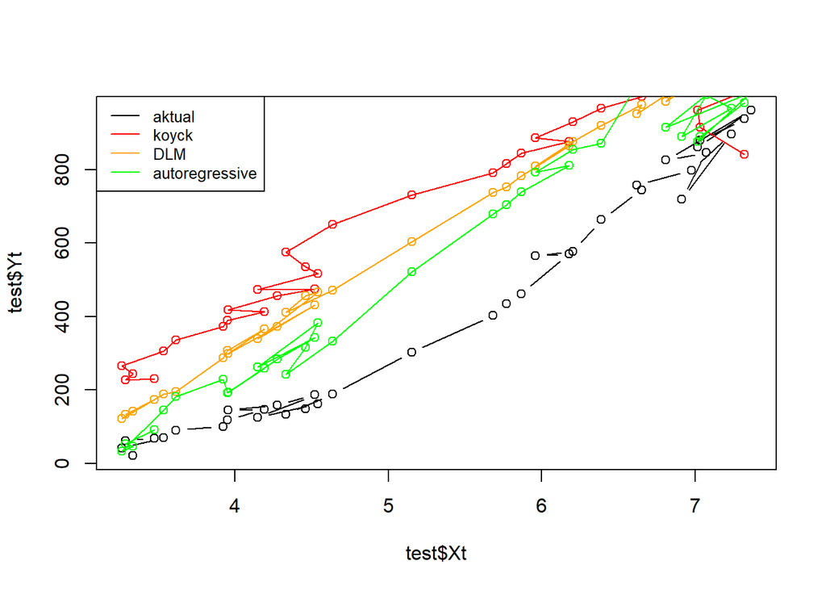

```r
par(mfrow=c(1,1))
plot(test$Xt, test$Yt, type="b", col="black")
points(test$Xt, fore.koyck$forecasts,col="red")
lines(test$Xt, fore.koyck$forecasts,col="red")
points(test$Xt, fore.dlm2$forecasts,col="orange")
lines(test$Xt, fore.dlm2$forecasts,col="orange")
points(test$Xt, fore.ardl$forecasts,col="green")
lines(test$Xt, fore.ardl$forecasts,col="green")
legend("topleft",c("aktual", "koyck","DLM", "autoregressive"), lty=1, col=c("black","red","orange","green"), cex=0.8)
```

Berdasarkan plot tersebut, terlihat bahwa plot yang paling mendekati data aktualnya adalah Model Autoregressive (ARDL), sehingga dapat disimpulkan model terbaik dalam hal ini adalah model regresi autoregressive (dynamic regression).

## 13. Diagnostik Model

### 13.1 Uji Non Autokorelasi

H0: tidak ada autokorelasi

H1: Ada autokorelasi

```r
bgtest(model.ardl$model)
```

```
##
##  Breusch-Godfrey test for serial correlation of order up to 1
##
## data:  model.ardl$model
## LM test = 4.7043, df = 1, p-value = 0.03009
```

Karena p-value<0.05, maka tolak H0. Dengan kata lain, cukup bukti untuk menyatakan bahwa terdapat autokorelasi pad amodel awal dengan taraf nyata 5%. Autokorelasi pada model masih belum berhasil ditangani, sehingga perlu dilakukan penanganan dengan metode lain.

### 13.2 Uji Heterogenitas

H0: Tidak adanya heteroskedatisitas (ragam sisaan homogen)

H1: Adanya heteroskedastisitas (ragam sisaan heterogen)

```r
bptest(model.ardl$model)
```

```
##
##  studentized Breusch-Pagan test
##
## data:  model.ardl$model
## BP = 14.147, df = 20, p-value = 0.823
```

Berdasarkan uji Breush Pagan diperoleh nilai p-value>0.05 sehingga tidak tolak H0, atau belum cukup bukti untuk mengatakan ragam sisaan heterogen atau dapat dikatakan ragam sisaan homogen pada taraf nyata 5%.

## 14. Kesimpulan

Metode yang paling cocok untuk peramalan terbaik yaitu metode dengan model autoregressive (dynamic regression). Hasil uji diagnostik menunjukkan bahwa dengan metode tersebut autokorelasi pada model regresi deret waktu belum berhasil ditangani, sehingga perlu dilakukan uji lanjut atau penanganan dengan metode lain.

## 15. Daftar Pustaka

Bektiarso, S., Mahardika, I. K., Anggraeni, N. M., & Jannah, N. A. (2023). Kemampuan Alat Kincir Angin Sederhana Dalam Menghasilkan Listrik. *Jurnal Ilmiah Wahana Pendidikan*, *9*(3), 488-493.

Gujarati, D. N. (2004). Basic Econometrics.Fourth Edition. New York: The McGraw-Hill.

Gujarati, D. N. (2006). Essentials of Econometrics. Third Edition. New York: The McGraw-Hill.

Lubis, Z. (2018). Metode baru merancang sistemmekanis kincir angin pembangkit listrik tenaga angin. *JET (Journal of Electrical Technology)*, *3*(3), 163-166.